# Effect sizes

Understanding, choosing and computing the currency of meta-analysis

Damien Beillouin

CIRAD, UPR HortSys

## Learning objectives

By the end of this session, you will be able to:

1. Explain what an **effect size** is and why each one comes with a **sampling variance**.
2. **Choose** the right metric for your data: mean difference, Hedges’ *g*, log response ratio, log odds ratio, Fisher’s *z*.
3. **Compute** them by hand and with `metafor::escalc()`.
4. Recognise the **traps**: small samples, near-zero means, missing SDs, unsafe conversions.

# What is an effect size?

## Studies do not speak the same language

Each of the 888 comparisons gives a **mean in the intervention** (intercropping) and a **mean in the comparator** (monoculture), each in the study’s own unit: per trap, per plant, per m²…

The raw differences (+115, −5.6, −0.035) cannot be compared. The **ratio** can: two studies halve the abundance, one barely changes it.

An effect size compares the **intervention mean with the comparator mean** on **one common scale** (direction and magnitude), and comes with its **uncertainty**.

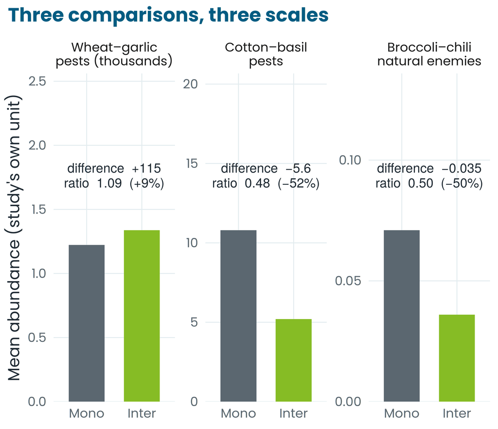

Source: three comparisons from Jones et al. (2021).

## Why not just use p-values?

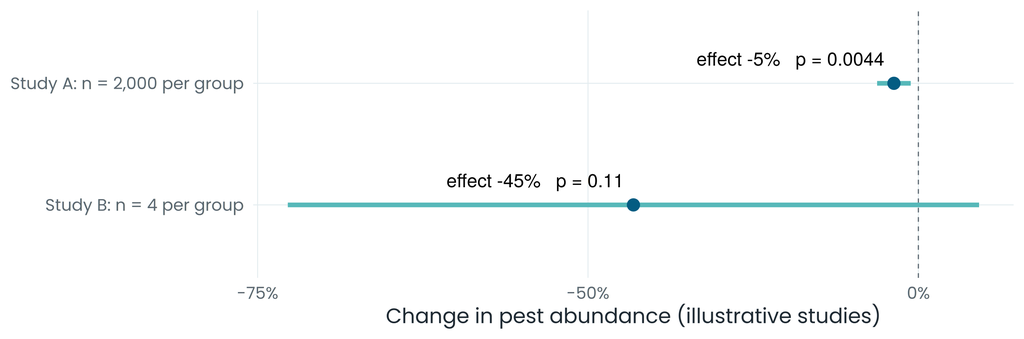

A p-value mixes **effect size** and **sample size**: a tiny effect can be “highly significant”, a large one “not significant”.

Meta-analysis combines **effect sizes and their uncertainty**, not p-values (Nakagawa and Cuthill 2007).

## Every study sees the truth through noise

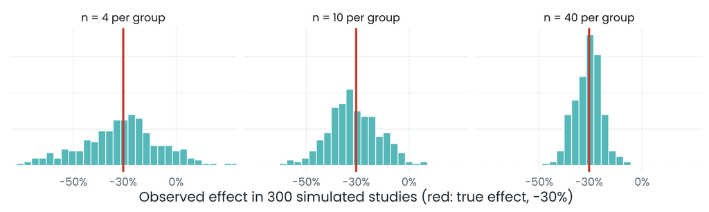

$$\hat\theta_k = \theta_k + \varepsilon_k \qquad \text{observed} = \text{true} + \text{sampling error}, \quad \text{Var}(\varepsilon_k) = v_k$$

Each effect size comes with its **sampling variance** $v_k$. In the meta-analysis this afternoon, each study is **weighted** by the inverse of its variance, $w_k = 1/v_k$: precise studies count more. (In a random-effects model, the weight also includes the real variation between studies, $\tau^2$: $w_k = 1/(v_k + \tau^2)$.)

# Which metric for which data?

## A decision tree

**Continuous outcome, two groups**  
means, SD, n

- Same unit everywhere → **Mean difference (MD)**
- Scores or indices, each study with its own scale → **standardised mean difference** (Hedges' *g*)
- Quantities: counts, biomass, yield → **log response ratio (lnRR)**

**Binary outcome, two groups**  
counts in a 2×2 table

- Presence/absence, survival, infestation → **log odds ratio** (or log risk ratio)

**Relationship between two continuous variables**  
correlation r, n

- e.g. yield vs landscape complexity → **Fisher's *z***

Test: does **“twice as many”** make sense?  
Yes (aphids, yield) → **lnRR**.  
No (a damage score of 4 is not “twice” a score of 2) → *g*.

Our running example → **lnRR**. Fix the metric **in the protocol**, before seeing the results.

Show of hands: *which metric for your own data?*

## Our worked example

Aphids on fennel, **intercropped with cotton** vs **fennel monoculture** (Fernandes et al. 2013), one comparison of our dataset:

|  | Intercropping (T) | Monoculture (C) |
| --- | --- | --- |
| Mean | 8.37 | 23.98 |
| SD | 2.85 | 5.46 |
| n | 4 | 4 |

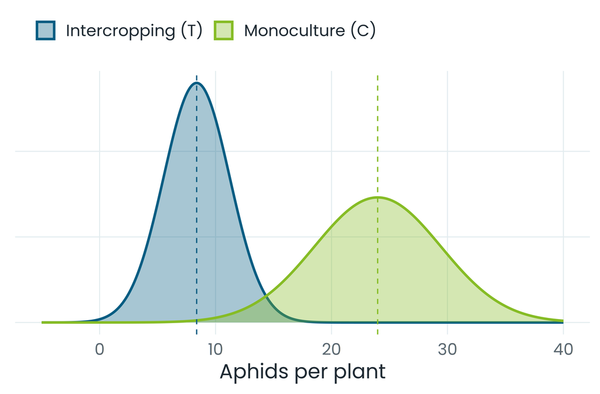

Convention for the whole week: **T (intervention) in the numerator / first**, C (comparator) second. A negative effect = fewer pests with intercropping.

## The log response ratio (lnRR)

$$\ln RR = \ln\left(\frac{\bar X_T}{\bar X_C}\right)$$

$$v_{\ln RR} = \frac{SD_T^2}{n_T \bar X_T^2} + \frac{SD_C^2}{n_C \bar X_C^2}$$

(Hedges et al. 1999)

**Back to percent** for reporting:

$$\text{change} = 100 \times \left(e^{\ln RR} - 1\right)\%$$

Why the log? The ratio is **asymmetric** (halving = 0.5, doubling = 2); its log is **symmetric** (−0.69, +0.69) and closer to normal.

Why ecologists like it **Unit-free** and **proportional**: “intercropping reduces aphids by 65%” speaks to agronomists — and its value does not depend on the SD (only its variance does).

## Exercise 1 · By hand (pairs, 8 min)

Calculator ready

With the aphid example (T: 8.37 ± 2.85, n = 4; C: 23.98 ± 5.46, n = 4), compute **lnRR**, its **variance**, and the **% change**.

lnRR = ln(8.37 / 23.98) = **-1.053**  
*v* = 2.85² / (4 × 8.37²) + 5.46² / (4 × 23.98²) = **0.0419** (SE = 0.205)  
Change = 100 × (e<sup>-1.053</sup> − 1) = **-65%**

## Now let R do it (live coding, 5 min)

Predict first What value of yi should R return for our aphid example?

```r
library(metafor)
# ic <- read.csv("intercropping_biodiversity.csv")      # running example

dat <- escalc(measure = "ROM",                           # lnRR ("ratio of means")
              m1i = b_mean_t, sd1i = b_sd_t, n1i = b_n_t,  # T = intercropping
              m2i = b_mean_c, sd2i = b_sd_c, n2i = b_n_c,  # C = monoculture
              data = ic)
# other metrics: measure = "SMD" (Hedges' g), "OR", "ZCOR"

dat[dat$es_id == 2011, c("es_id", "yi", "vi")]          # our worked example
```

```
    es_id      yi     vi
137  2011 -1.0526 0.0419
```

```r
c(NA_yi = sum(is.na(dat$yi)), vi_zero = sum(dat$vi == 0, na.rm = TRUE))  # what to deal with
```

```
  NA_yi vi_zero
    156      46
```

- `yi` = effect size, `vi` = sampling variance: **the input of every meta-analysis** (`rma()`, this afternoon).
- Zero mean → `NA`; zero SD → `vi = 0` (“infinite” precision!): **count both** before `rma()`.

## Hedges’ *g*, step by step

**Idea**: express the difference in **standard-deviation units**.

$$d = \frac{\bar X_T - \bar X_C}{SD_{pooled}}$$

Useful when studies use **different scales** (scores, indices), where “twice as many” means nothing.

Small samples **inflate** *d* → multiply by a correction *J* < 1: that is **Hedges’ *g*** (Hedges 1981).

With our aphids:

**1.** Difference: 8.37 − 23.98 = **-15.61** aphids

**2.** Pooled SD (equal *n*: average the variances): √((2.85² + 5.46²) / 2) = **4.36**

**3.** *d* = -15.61 / 4.36 = **-3.58** standard deviations

**4.** With 4 + 4 plants, *J* = 0.87 → *g* = **-3.12**

`escalc(measure = "SMD")` does all of this — and the variance. You never compute *g* by hand in practice.

# The traps

## Trap 1 · Means close to zero

Your call

156 comparisons in our data have a **zero mean**. What do you do with them for a lnRR?

**Exact zeros**: no lnRR (and most also have SD = 0, so no *g*). Report them; test the conclusion **with and without**.

**Near zero**: lnRR is biased. Geary’s rule: each mean ≥ **3 SE** from zero → **28%** of our usable comparisons fail it.

What to do

- Near zero or small *n*: **bias-corrected lnRR** (Lajeunesse 2015) — formula and R code on the handout.
- **Never** add an arbitrary constant (+1) without testing its influence.

## Trap 2 · Missing or disguised SDs

The common case: a standard error **SD = SE × √n**  
553 of our 888 comparisons were reported with a SE.

Also possible: from a 95% CI, or from a median and IQR (Wan et al. 2014) — see the formula sheet.

**215** comparisons (**24%**) have **no usable SD**.  
Never set it to 0 or drop silently. Robust fix for lnRR: compute the sampling variance from the **typical coefficient of variation** of the other studies (CV = SD/mean, averaged with weights *n*, then squared) (Nakagawa et al. 2023), after screening implausible CVs (Wednesday 16:15). Not possible for zero means.

Traps 1 and 2 together: **224** of 888 comparisons (25%) are unusable as such for lnRR. This afternoon we set them aside — and say so.

## Trap 3 · lnRR and *g*: same direction, different magnitudes

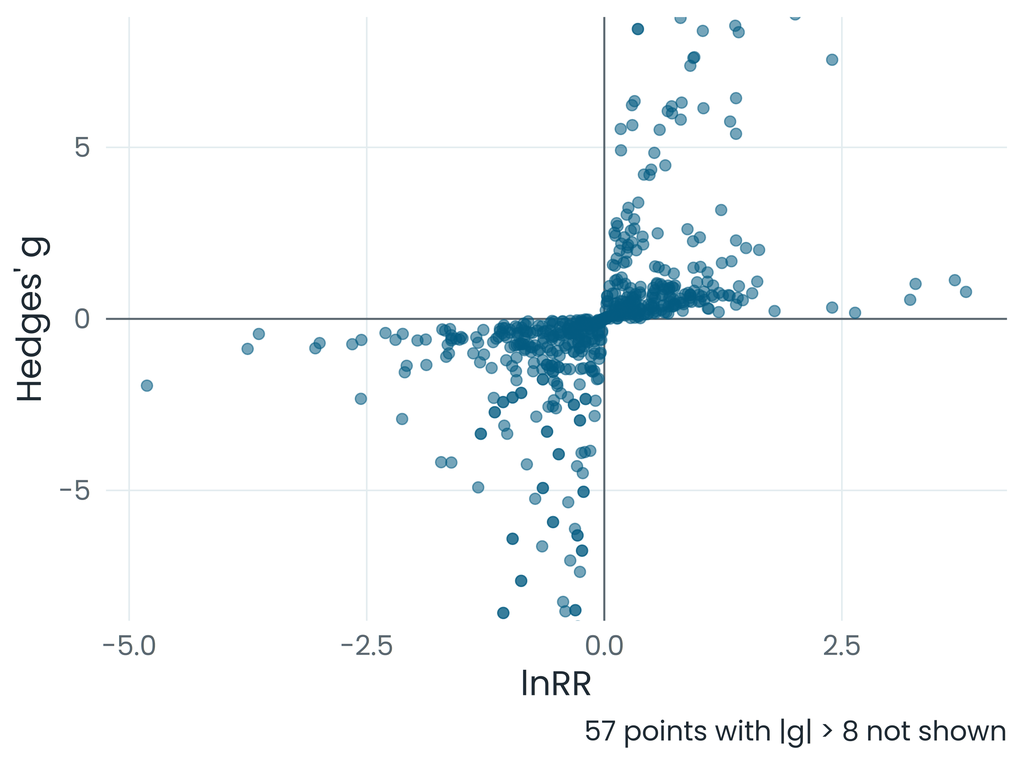

The 664 usable comparisons, computed both ways:

- Same **direction** always (both follow $\bar X_T - \bar X_C$)
- Similar **ranking** (Spearman ρ = 0.84)
- But very different **magnitudes**: *g* explodes when the SD is tiny

*g* depends on the SD (trap size, plot size, subsamples); lnRR does not. **Never mix both** in one analysis, and do not convert lnRR ↔︎ *g*.

## Other kinds of data, in one slide

Yes/no outcomes Plants infested or not, seedlings alive or dead → a 2×2 table of counts → **log odds ratio** (or log risk ratio, the log of the ratio of proportions).  
`escalc("OR", ai=, bi=, ci=, di=)`

Correlations e.g. habitat cover vs pest control → **Fisher’s *z***.  
Pool *z*, not *r*, then back-transform.  
`escalc("ZCOR", ri=, ni=)`

Conversions between metrics Possible (log OR → *d*, *r* → *d*), but only for a **minority** of studies: flag them and run a **sensitivity analysis** without them. **Never lnRR ↔︎ *g***. Formulas in the formula sheet (Borenstein et al. 2021 chap. 7).

## Quick quiz

**1.** Earthworm biomass (g/m²) under conservation vs conventional tillage, studies in many different units. Metric?

**lnRR** — positive, proportional, unit-free.

**2.** lnRR = −0.36. Change in %?

100 × (e<sup>−0.36</sup> − 1) = **−30%**.

**3.** Proportion of fields where a weed is present, with vs without cover crop. Metric?

**log odds ratio** (or log risk ratio).

**4.** Why use *g* rather than *d*?

*d* **overestimates |effect|** in small samples; *g* corrects it.

## Key messages

1. **Effect size + sampling variance** = the unit of every meta-analysis; the variance becomes the **weight**.
2. The **data and the question** choose the metric: MD, *g*, lnRR, log OR, *z*. Fix it in the protocol.
3. lnRR: check **Geary**, correct small-sample **bias**, handle **zeros** and **missing SDs** explicitly.
4. Never mix **non-convertible** metrics (lnRR ↔︎ *g*); flag and test any conversion.

## Going further

**All formulas** (with the exact *J*, bias-corrected lnRR and its variance, conversions and their variances): see the **A4 formula sheet** handout.

- **Variability as an outcome**: lnCVR, the log ratio of coefficients of variation (Nakagawa et al. 2015).
- **Paired / before–after designs** (SMCC, ROMC in `escalc`) need the correlation between measurements.
- **Several treatments vs one control** create **dependent** effect sizes → multilevel models, this afternoon.

# Extra, if time remains

## Can we just average the percentages?

Same 440 pest comparisons, two “averages” (unweighted):

- mean of the % changes: **+33%**
- back-transformed mean lnRR: **-25%**

Why so different? A % change is **asymmetric**: halving gives −50%, doubling gives +100%. A few large increases pull the mean of percentages up. Average on the **log scale**, back-transform at the end.

## Which effect size?

Pairs, 3 minutes

For each case, which effect size would you use?

1. Presence or absence of a pest in 20 intercropped and 20 monoculture fields.
2. Wheat yield in t/ha, same unit in every study.
3. Species richness, with several monocultures at **zero**.
4. Correlation between landscape complexity and pest abundance across farms.

1 · log **odds ratio** (`"OR"`) · 2 · **mean difference** (`"MD"`) or lnRR if you want a relative effect · 3 · **SMD** (`"SMD"`), lnRR is undefined · 4 · **Fisher’s z** (`"ZCOR"`)

## In the online notebook

Each point of this session developed further, with the same data, more pitfalls and exercises with solutions:

- [Effect sizes](https://literaturesynthesis.github.io/notebook/chapters/effect-sizes.html)
- [Formula sheet (appendix)](https://literaturesynthesis.github.io/notebook/chapters/formulas.html)
- [From research question to estimand](https://literaturesynthesis.github.io/notebook/chapters/question-estimand.html)
- [Dependence: map it before you model it](https://literaturesynthesis.github.io/notebook/chapters/dependence.html)

**literaturesynthesis.github.io/notebook**

## References

Borenstein, M., L. V. Hedges, J. P. T. Higgins, and H. R. Rothstein. 2021. Introduction to meta-analysis. Second edition. Wiley, Chichester.

Fernandes, F. S., F. S. Ramalho, W. A. C. Godoy, J. K. S. Pachu, R. B. Nascimento, J. B. Malaquias, and J. C. Zanuncio. 2013. [Within plant distribution and dynamics of *hyadaphis foeniculi* (Hemiptera: Aphididae) in field fennel intercropped with naturally colored cotton](https://doi.org/10.1653/024.096.0112). Florida Entomologist 96.

Hedges, L. V. 1981. [Distribution theory for Glass’s estimator of effect size and related estimators](https://doi.org/10.3102/10769986006002107). Journal of Educational Statistics 6:107–128.

Hedges, L. V., J. Gurevitch, and P. S. Curtis. 1999. The meta-analysis of response ratios in experimental ecology. Ecology 80:1150–1156.

Jones, S. K., A. C. Sánchez, S. D. Juventia, and N. Estrada-Carmona. 2021. [A global database of diversified farming effects on biodiversity and yield](https://doi.org/10.1038/s41597-021-01000-y). Scientific Data 8:212.

Lajeunesse, M. J. 2015. [Bias and correction for the log response ratio in ecological meta-analysis](https://doi.org/10.1890/14-2402.1). Ecology 96:2056–2063.

Nakagawa, S., and I. C. Cuthill. 2007. [Effect size, confidence interval and statistical significance: A practical guide for biologists](https://doi.org/10.1111/j.1469-185X.2007.00027.x). Biological Reviews 82:591–605.

Nakagawa, S., D. W. A. Noble, M. Lagisz, R. Spake, W. Viechtbauer, and A. M. Senior. 2023. [A robust and readily implementable method for the meta-analysis of response ratios with and without missing standard deviations](https://doi.org/10.1111/ele.14144). Ecology Letters 26:232–244.

Nakagawa, S., R. Poulin, K. Mengersen, K. Reinhold, L. Engqvist, M. Lagisz, and A. M. Senior. 2015. [Meta-analysis of variation: Ecological and evolutionary applications and beyond](https://doi.org/10.1111/2041-210X.12309). Methods in Ecology and Evolution 6:143–152.

Wan, X., W. Wang, J. Liu, and T. Tong. 2014. [Estimating the sample mean and standard deviation from the sample size, median, range and/or interquartile range](https://doi.org/10.1186/1471-2288-14-135). BMC Medical Research Methodology 14:135.